# HW3-Plane

Hakan Ekiz - IE48B - Fall2021

13 Aralık 2021

## Homework Information

### Distance Measurements

1- Euclidian 2- DTW (Windows size=10) 3- DTW (Window size=20) 4- ERP

### K nn classifiers

1- k=1 2- k=3 3- k=5

### Datasets

1- ECG200 2- Plane 3- SyntheticControl 4- Trace 5- SmoothSubspace

Note: Since it takes time to run 5 different datasets in the same file and convert them to reports, 5 different files will be loaded for 5 different datasets.

## Libraries and Functions

```r
require(data.table)
require(ggplot2)
require(repr)
require(rpart)
require(rattle)
require(TSrepr)
require(TSdist)
require(dtw)
require(zoo)
require(genlasso)
require(e1071)
```

```r
options(repr.plot.width=15, repr.plot.height=8)
```

```r
nn_classify_cv=function(dist_matrix,train_class,test_indices,k=1){

    test_distances_to_train=dist_matrix[test_indices,]
    test_distances_to_train=test_distances_to_train[,-test_indices]
    train_class=train_class[-test_indices]
    #print(str(test_distances_to_train))
    ordered_indices=apply(test_distances_to_train,1,order)
    if(k==1){
        nearest_class=as.numeric(trainclass[as.numeric(ordered_indices[1,])])
        nearest_class=data.table(id=test_indices,nearest_class)
    } else {
        nearest_class=apply(ordered_indices[1:k,],2,function(x) {trainclass[x]})
        nearest_class=data.table(id=test_indices,t(nearest_class))
    }

    long_nn_class=melt(nearest_class,'id')

    class_counts=long_nn_class[,.N,list(id,value)]
    class_counts[,predicted_prob:=N/k]
    wide_class_prob_predictions=dcast(class_counts,id~value,value.var='predicted_prob')
    wide_class_prob_predictions[is.na(wide_class_prob_predictions)]=0
    class_predictions=class_counts[,list(predicted=value[which.max(N)]),by=list(id)]


    return(list(prediction=class_predictions,prob_estimates=wide_class_prob_predictions))

}
```

# Plane

## Data

Train Size=105 TestSize=105 Length=144 Number of Class=7

```r
current_folder=getwd()
dataset='Plane'
main_path=sprintf('%s/ClassificationData/%s/%s',current_folder,dataset,dataset)

dist_path=sprintf('%s/ClassificationData/%s/distances/%s',current_folder,dataset,dataset)

train_data_path=sprintf('%s_TRAIN.txt',main_path)
traindata=as.matrix(fread(train_data_path))

test_data_path=sprintf('%s_TEST.txt',main_path)
testdata=as.matrix(fread(test_data_path))

#first column is the class variable
trainclass=traindata[,1] # takes -1 and 1
testclass=testdata[,1] # takes -1 and 1

#drop first column
traindata=traindata[,2:ncol(traindata)]
testdata=testdata[,2:ncol(testdata)]

# instance characteristics
tlength=ncol(traindata)
n_series_train=nrow(traindata)
n_series_test=nrow(testdata)
```

```r
head(data.table(traindata))
```

```
##          V2        V3        V4        V5        V6          V7         V8
## 1: 2.483940 2.2762865 2.0675157 1.9218926 1.7187752  1.50842850  1.3006752
## 2: 2.603320 2.3406991 2.0822848 1.8256242 1.5677057  1.31220300  1.0571948
## 3: 2.757321 2.5766667 2.3633233 2.1515785 1.9402183  1.72942750  1.5194285
## 4: 0.916063 0.7201453 0.5224446 0.3258262 0.1343814 -0.05401188 -0.2355249
## 5: 2.656142 2.3881447 2.1185954 1.8496769 1.5765789  1.31016860  1.1096989
## 6: 2.716798 2.5208585 2.3196204 2.1164411 1.9136371  1.71124980  1.5093279
##            V9        V10        V11         V12        V13         V14
## 1:  1.0902862  0.8827328  0.6723009  0.46338263  0.2545249  0.04573843
## 2:  0.8017157  0.5466832  0.2918485  0.03662012 -0.0761458 -0.07734542
## 3:  1.3095473  1.1002525  0.8914930  0.68316216  0.4828424  0.29863458
## 4: -0.4096045 -0.5744532 -0.7823530 -1.00531810 -1.2279865 -1.44269340
## 5:  0.9309980  0.7506683  0.5393333  0.28010942  0.2027687  0.22508711
## 6:  1.3046473  1.1036170  0.8995841  0.69586494  0.5034464  0.33700001
##           V15         V16        V17        V18        V19        V20
```

[output cut: 153 more lines]

```r
dt_ts_train=data.table(traindata)
dt_ts_train[,id:=1:.N]
long_train=melt(dt_ts_train,id.vars=c('id'))
long_train[,time:=as.numeric(gsub("\\D", "", variable))-1]
long_train=long_train[order(id,time)]
long_train[,diff_series:=value-shift(value,1),by=list(id)]
head(long_train)
```

```
##    id variable    value time diff_series
## 1:  1       V2 2.483940    1          NA
## 2:  1       V3 2.276286    2  -0.2076532
## 3:  1       V4 2.067516    3  -0.2087708
## 4:  1       V5 1.921893    4  -0.1456231
## 5:  1       V6 1.718775    5  -0.2031174
## 6:  1       V7 1.508428    6  -0.2103467
```

```r
head(dt_ts_train)
```

```
##          V2        V3        V4        V5        V6          V7         V8
## 1: 2.483940 2.2762865 2.0675157 1.9218926 1.7187752  1.50842850  1.3006752
## 2: 2.603320 2.3406991 2.0822848 1.8256242 1.5677057  1.31220300  1.0571948
## 3: 2.757321 2.5766667 2.3633233 2.1515785 1.9402183  1.72942750  1.5194285
## 4: 0.916063 0.7201453 0.5224446 0.3258262 0.1343814 -0.05401188 -0.2355249
## 5: 2.656142 2.3881447 2.1185954 1.8496769 1.5765789  1.31016860  1.1096989
## 6: 2.716798 2.5208585 2.3196204 2.1164411 1.9136371  1.71124980  1.5093279
##            V9        V10        V11         V12        V13         V14
## 1:  1.0902862  0.8827328  0.6723009  0.46338263  0.2545249  0.04573843
## 2:  0.8017157  0.5466832  0.2918485  0.03662012 -0.0761458 -0.07734542
## 3:  1.3095473  1.1002525  0.8914930  0.68316216  0.4828424  0.29863458
## 4: -0.4096045 -0.5744532 -0.7823530 -1.00531810 -1.2279865 -1.44269340
## 5:  0.9309980  0.7506683  0.5393333  0.28010942  0.2027687  0.22508711
## 6:  1.3046473  1.1036170  0.8995841  0.69586494  0.5034464  0.33700001
##           V15         V16        V17        V18        V19        V20
```

[output cut: 153 more lines]

```r
dt_ts_test=data.table(testdata)
dt_ts_test[,id:=1:.N]
long_test=melt(dt_ts_test,id.vars=c('id'))
long_test[,time:=as.numeric(gsub("\\D", "", variable))-1]
long_test=long_test[order(id,time)]
long_test[,diff_series:=value-shift(value,1),by=list(id)]
head(long_test)
```

```
##    id variable    value time diff_series
## 1:  1       V2 2.684302    1          NA
## 2:  1       V3 2.453768    2  -0.2305346
## 3:  1       V4 2.230384    3  -0.2233833
## 4:  1       V5 2.011169    4  -0.2192152
## 5:  1       V6 1.794118    5  -0.2170510
## 6:  1       V7 1.577387    6  -0.2167312
```

```r
head(dt_ts_test)
```

```
##           V2        V3        V4        V5        V6           V7         V8
## 1: 2.6843023 2.4537677 2.2303844 2.0111692 1.7941182  1.577387000  1.3596800
## 2: 2.4726101 2.2356114 2.0139566 1.8142436 1.5865378  1.366993800  1.1509717
## 3: 2.6121085 2.4104065 2.2095360 2.0090774 1.8084274  1.607661700  1.4103988
## 4: 0.9186073 0.7087953 0.5209432 0.3422712 0.1677084 -0.005989314 -0.1790123
## 5: 2.5832793 2.3290317 2.0775394 1.8262124 1.5757194  1.325423600  1.0920131
## 6: 2.6058801 2.3382851 2.0739915 1.8118079 1.5505170  1.290509000  1.0325340
##            V9        V10        V11          V12         V13         V14
## 1:  1.1444859  0.9271364  0.7129035  0.513699800  0.34196826  0.18038965
## 2:  0.9424066  0.7263061  0.5103663  0.294617610  0.08288335 -0.12922045
## 3:  1.2089326  1.0075043  0.8046867  0.606389750  0.40519467  0.20597148
## 4: -0.3389830 -0.4961219 -0.6678103 -0.903885220 -1.14977830 -1.39302640
## 5:  0.9339144  0.7616182  0.6078871  0.421477780  0.17801705  0.05164702
## 6:  0.7720931  0.5128280  0.2538887 -0.005041752 -0.15522662 -0.08855468
##             V15         V16         V17        V18        V19        V20
```

[output cut: 153 more lines]

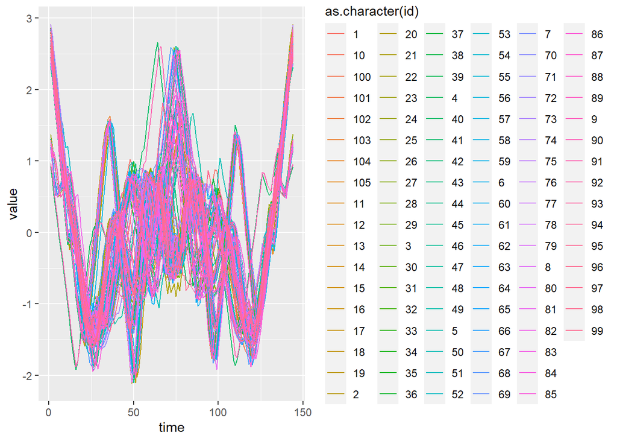

```r
ggplot(long_train, aes(time,value)) + geom_line(aes(color=as.character(id)))
```

## Representations

PAA with segmenth length = 5 PLA with n_important = 10 Tree with maxdepth = 12

```r
#Piecewise Aggregate + Piecewise Linear Approximation + Tree


segmentlength = 5
n_important = 10

long_train=long_train[order(id,time)]

treeres <- vector('list', n_series_train)
paares <- vector('list', n_series_train)

for (i in 1:n_series_train) {

  data_plot=long_train[id==i]

  data_ts=long_train[id==i]$value
  paa_rep=repr_paa(data_ts, segmentlength , meanC)
  dummy_time = c(1:(length(paa_rep)-1))*segmentlength
  dummy_time = c(dummy_time, (nrow(data_plot)))
  dt_paa = data.table(time=dummy_time, paa_rep)

  pla_rep=repr_pla(data_ts, times = n_important, return = "points")
  pla_rep=repr_pla(data_ts, times = n_important, return = "both")
  setnames(pla_rep,c('places','points'),c('time','pla_rep'))
  pla_rep$time=pla_rep$time+1


  tree=rpart(value~time,data_plot,control=rpart.control(cp=0,maxdepth=12,minsplit=20,minbucket=10))
  data_plot[,tree_rep:=predict(tree,data_plot)]


  data_plot=merge(data_plot,dt_paa,by='time',all.x=T)
  data_plot=merge(data_plot,pla_rep,by='time',all.x=T)

  data_plot[,paa_rep:=nafill(paa_rep,'nocb')]
  data_plot[, pla_rep := na.approx(pla_rep)]

  paares[[i]]=data_plot

}
results <- rbindlist(paares)
```

```r
head(results)
```

```
##    time id variable    value diff_series tree_rep  paa_rep  pla_rep
## 1:    1  1       V2 2.483940          NA 1.592283 2.093682 2.483940
## 2:    2  1       V3 2.276286  -0.2076532 1.592283 2.093682 2.354702
## 3:    3  1       V4 2.067516  -0.2087708 1.592283 2.093682 2.225465
## 4:    4  1       V5 1.921893  -0.1456231 1.592283 2.093682 2.096228
## 5:    5  1       V6 1.718775  -0.2031174 1.592283 2.093682 1.966991
## 6:    6  1       V7 1.508428  -0.2103467 1.592283 1.090885 1.837753
```

Sample representaion for id=10

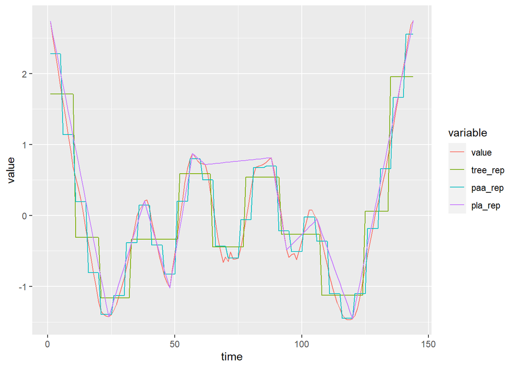

```r
selected=results[id==10]
data_show=melt(selected,id.vars='time',measure.vars=c('value','tree_rep', 'paa_rep', 'pla_rep'))
ggplot(data_show,aes(x=time,y=value,color=variable))+
    geom_line()
```

## Distance Measurement

Preliminary work with results dataset for future distance calculations;

Euc Dtw (window size = 10) Dtw (window size = 20) ERP

```r
value_train=dcast(results[!is.na(value)],id~time,value.var='value')
head(value_train)
```

```
##    id        1         2         3         4         5           6          7
## 1:  1 2.483940 2.2762865 2.0675157 1.9218926 1.7187752  1.50842850  1.3006752
## 2:  2 2.603320 2.3406991 2.0822848 1.8256242 1.5677057  1.31220300  1.0571948
## 3:  3 2.757321 2.5766667 2.3633233 2.1515785 1.9402183  1.72942750  1.5194285
## 4:  4 0.916063 0.7201453 0.5224446 0.3258262 0.1343814 -0.05401188 -0.2355249
## 5:  5 2.656142 2.3881447 2.1185954 1.8496769 1.5765789  1.31016860  1.1096989
## 6:  6 2.716798 2.5208585 2.3196204 2.1164411 1.9136371  1.71124980  1.5093279
##             8          9         10          11         12          13
## 1:  1.0902862  0.8827328  0.6723009  0.46338263  0.2545249  0.04573843
## 2:  0.8017157  0.5466832  0.2918485  0.03662012 -0.0761458 -0.07734542
## 3:  1.3095473  1.1002525  0.8914930  0.68316216  0.4828424  0.29863458
## 4: -0.4096045 -0.5744532 -0.7823530 -1.00531810 -1.2279865 -1.44269340
## 5:  0.9309980  0.7506683  0.5393333  0.28010942  0.2027687  0.22508711
## 6:  1.3046473  1.1036170  0.8995841  0.69586494  0.5034464  0.33700001
##            14          15         16         17         18         19
```

[output cut: 153 more lines]

```r
value_train=as.matrix(value_train)
```

```r
diff_train=dcast(results[!is.na(diff_series)],id~time,value.var='diff_series')
head(diff_train)
```

```
##    id          2          3          4          5          6          7
## 1:  1 -0.2076532 -0.2087708 -0.1456231 -0.2031174 -0.2103467 -0.2077533
## 2:  2 -0.2626211 -0.2584143 -0.2566606 -0.2579185 -0.2555027 -0.2550082
## 3:  3 -0.1806546 -0.2133434 -0.2117448 -0.2113602 -0.2107908 -0.2099990
## 4:  4 -0.1959177 -0.1977007 -0.1966184 -0.1914449 -0.1883932 -0.1815130
## 5:  5 -0.2679977 -0.2695493 -0.2689185 -0.2730980 -0.2664103 -0.2004697
## 6:  6 -0.1959393 -0.2012381 -0.2031793 -0.2028040 -0.2023873 -0.2019219
##             8          9         10         11          12           13
## 1: -0.2103890 -0.2075534 -0.2104320 -0.2089182 -0.20885770 -0.208786497
## 2: -0.2554791 -0.2550325 -0.2548347 -0.2552284 -0.11276593 -0.001199616
## 3: -0.2098812 -0.2092948 -0.2087595 -0.2083309 -0.20031977 -0.184207810
## 4: -0.1740796 -0.1648487 -0.2078997 -0.2229651 -0.22266840 -0.214706900
## 5: -0.1787009 -0.1803296 -0.2113351 -0.2592239 -0.07734075  0.022318440
## 6: -0.2046806 -0.2010303 -0.2040329 -0.2037191 -0.19241854 -0.166446390
##             14          15         16         17         18         19
```

[output cut: 153 more lines]

```r
diff_train=as.matrix(diff_train)
```

```r
tree_train=dcast(results[!is.na(tree_rep)],id~time,value.var='tree_rep')
head(tree_train)
```

```
##    id          1          2          3          4          5          6
## 1:  1 1.59228333 1.59228333 1.59228333 1.59228333 1.59228333 1.59228333
## 2:  2 1.44292793 1.44292793 1.44292793 1.44292793 1.44292793 1.44292793
## 3:  3 1.83392569 1.83392569 1.83392569 1.83392569 1.83392569 1.83392569
## 4:  4 0.05629129 0.05629129 0.05629129 0.05629129 0.05629129 0.05629129
## 5:  5 1.52300054 1.52300054 1.52300054 1.52300054 1.52300054 1.52300054
## 6:  6 1.81157810 1.81157810 1.81157810 1.81157810 1.81157810 1.81157810
##             7          8          9         10          11          12
## 1: 1.59228333 1.59228333 1.59228333 1.59228333 -0.34905331 -0.34905331
## 2: 1.44292793 1.44292793 1.44292793 1.44292793 -0.88070296 -0.88070296
## 3: 1.83392569 1.83392569 1.83392569 1.83392569 -0.15535815 -0.15535815
## 4: 0.05629129 0.05629129 0.05629129 0.05629129 -1.49006887 -1.49006887
## 5: 1.52300054 1.52300054 1.52300054 1.52300054 -0.33007072 -0.33007072
## 6: 1.81157810 1.81157810 1.81157810 1.81157810 -0.07036415 -0.07036415
##             13          14          15          16          17          18
```

[output cut: 139 more lines]

```r
tree_train=as.matrix(tree_train)
```

```r
paa_train=dcast(results[!is.na(paa_rep)],id~time,value.var='paa_rep')
head(paa_train)
```

```
##    id         1         2         3         4         5          6          7
## 1:  1 2.0936819 2.0936819 2.0936819 2.0936819 2.0936819  1.0908847  1.0908847
## 2:  2 2.0839268 2.0839268 2.0839268 2.0839268 2.0839268  0.8019291  0.8019291
## 3:  3 2.3578216 2.3578216 2.3578216 2.3578216 2.3578216  1.3100298  1.3100298
## 4:  4 0.5237721 0.5237721 0.5237721 0.5237721 0.5237721 -0.4111895 -0.4111895
## 5:  5 2.1178277 2.1178277 2.1178277 2.1178277 2.1178277  0.9281734  0.9281734
## 6:  6 2.3174710 2.3174710 2.3174710 2.3174710 2.3174710  1.3056852  1.3056852
##             8          9         10          11          12          13
## 1:  1.0908847  1.0908847  1.0908847  0.07969444  0.07969444  0.07969444
## 2:  0.8019291  0.8019291  0.8019291 -0.19957648 -0.19957648 -0.19957648
## 3:  1.3100298  1.3100298  1.3100298  0.31109234  0.31109234  0.31109234
## 4: -0.4111895 -0.4111895 -0.4111895 -1.43030640 -1.43030640 -1.43030640
## 5:  0.9281734  0.9281734  0.9281734  0.16688167  0.16688167  0.16688167
## 6:  1.3056852  1.3056852  1.3056852  0.34756344  0.34756344  0.34756344
##             14          15         16         17         18         19
```

[output cut: 146 more lines]

```r
paa_train=as.matrix(paa_train)
```

```r
pla_train=dcast(results[!is.na(pla_rep)],id~time,value.var='pla_rep')
head(pla_train)
```

```
##    id        1        2         3         4         5         6         7
## 1:  1 2.483940 2.354702 2.2254652 2.0962279 1.9669907 1.8377534 1.7085162
## 2:  2 2.603320 2.393585 2.1838498 1.9741146 1.7643794 1.5546442 1.3449090
## 3:  3 2.757321 2.587900 2.4184790 2.2490579 2.0796367 1.9102156 1.7407944
## 4:  4 0.916063 0.868151 0.8202389 0.7723269 0.7244149 0.6765028 0.6285908
## 5:  5 2.656142 2.418539 2.1809358 1.9433325 1.7057292 1.4681259 1.2305226
## 6:  6 2.716798 2.530925 2.3450529 2.1591805 1.9733080 1.7874356 1.6015632
##            8         9        10        11        12          13         14
## 1: 1.5792789 1.4500417 1.3208044 1.1915672 1.0623299  0.93309266  0.8038554
## 2: 1.1351738 0.9254386 0.7157034 0.5059681 0.2962329  0.08649774 -0.1232375
## 3: 1.5713733 1.4019521 1.2325310 1.0631098 0.8936887  0.72426752  0.5548464
## 4: 0.5806788 0.5327667 0.4848547 0.4369427 0.3890307  0.34111862  0.2932066
## 5: 0.9929193 0.7553160 0.5177127 0.2801094 0.1277121 -0.02468521 -0.1770825
## 6: 1.4156907 1.2298183 1.0439458 0.8580734 0.6722010  0.48632853  0.3004561
##            15          16          17         18          19           20
```

[output cut: 146 more lines]

```r
pla_train=as.matrix(pla_train)
```

```r
large_number=10000
```

### Euclidian

Raw, difference, tree, paa(piecewise aggregate approximation with segmenth length 5) and pla values are used.

```r
# raw + euc
dist_euc=as.matrix(dist(value_train))
diag(dist_euc)=large_number
fwrite(dist_euc,sprintf('%s_euc_raw_dist.csv',dist_path),col.names=F)
```

```
## x being coerced from class: matrix to data.table
```

```r
# diif + euc
dist_diff=as.matrix(dist(diff_train))
diag(dist_diff)=large_number
fwrite(dist_diff,sprintf('%s_euc_diff_dist.csv',dist_path),col.names=F)
```

```
## x being coerced from class: matrix to data.table
```

```r
# tree + euc
dist_tree=as.matrix(dist(tree_train))
diag(dist_tree)=large_number
fwrite(dist_tree,sprintf('%s_euc_tree_dist.csv',dist_path),col.names=F)
```

```
## x being coerced from class: matrix to data.table
```

```r
# paa + euc
dist_paa=as.matrix(dist(paa_train))
diag(dist_paa)=large_number
fwrite(dist_paa,sprintf('%s_euc_paa_dist.csv',dist_path),col.names=F)
```

```
## x being coerced from class: matrix to data.table
```

```r
# pla + euc
dist_pla=as.matrix(dist(pla_train))
diag(dist_pla)=large_number
fwrite(dist_pla,sprintf('%s_euc_pla_dist.csv',dist_path),col.names=F)
```

```
## x being coerced from class: matrix to data.table
```

```r
# raw + DTW(Window size = 10)
dist_dtw=as.matrix(dtwDist(value_train, window.type='sakoechiba',window.size=10))
diag(dist_dtw)=large_number
fwrite(dist_dtw,sprintf('%s_dtw_raw_dist_10ws.csv',dist_path),col.names=F)
```

```
## x being coerced from class: matrix to data.table
```

```r
# diff + DTW(Window size = 10)
dist_dtw_diff=as.matrix(dtwDist(diff_train, window.type='sakoechiba',window.size=10))
diag(dist_dtw_diff)=large_number
fwrite(dist_dtw_diff,sprintf('%s_dtw_diff_dist_10ws.csv',dist_path),col.names=F)
```

```
## x being coerced from class: matrix to data.table
```

```r
# tree + DTW(window size = 10)
dist_dtw_tree=as.matrix(dtwDist(tree_train, window.type='sakoechiba',window.size=10))
diag(dist_dtw_tree)=large_number
fwrite(dist_dtw_tree,sprintf('%s_dtw_tree_dist_10ws.csv',dist_path),col.names=F)
```

```
## x being coerced from class: matrix to data.table
```

```r
# paa + DTW(window size = 10)
dist_dtw_paa=as.matrix(dtwDist(paa_train, window.type='sakoechiba',window.size=10))
diag(dist_dtw_paa)=large_number
fwrite(dist_dtw_paa,sprintf('%s_dtw_paa_dist_10ws.csv',dist_path),col.names=F)
```

```
## x being coerced from class: matrix to data.table
```

```r
# pla + DTW(window size = 10)
dist_dtw_pla=as.matrix(dtwDist(pla_train, window.type='sakoechiba',window.size=10))
diag(dist_dtw_pla)=large_number
fwrite(dist_dtw_pla,sprintf('%s_dtw_pla_dist_10ws.csv',dist_path),col.names=F)
```

```
## x being coerced from class: matrix to data.table
```

```r
# raw + DTW(Window size = 20)
dist_dtw2=as.matrix(dtwDist(value_train, window.type='sakoechiba',window.size=20))
diag(dist_dtw2)=large_number
fwrite(dist_dtw2,sprintf('%s_dtw_raw_dist_20ws.csv',dist_path),col.names=F)
```

```
## x being coerced from class: matrix to data.table
```

```r
# diff + DTW(Window size = 20)
dist_dtw_diff2=as.matrix(dtwDist(diff_train, window.type='sakoechiba',window.size=20))
diag(dist_dtw_diff2)=large_number
fwrite(dist_dtw_diff2,sprintf('%s_dtw_diff_dist_20ws.csv',dist_path),col.names=F)
```

```
## x being coerced from class: matrix to data.table
```

```r
# tree + DTW(window size = 20)
dist_dtw_tree2=as.matrix(dtwDist(tree_train, window.type='sakoechiba',window.size=20))
diag(dist_dtw_tree2)=large_number
fwrite(dist_dtw_tree2,sprintf('%s_dtw_tree_dist_20ws.csv',dist_path),col.names=F)
```

```
## x being coerced from class: matrix to data.table
```

```r
# paa + DTW(window size = 20)
dist_dtw_paa2=as.matrix(dtwDist(paa_train, window.type='sakoechiba',window.size=20))
diag(dist_dtw_paa2)=large_number
fwrite(dist_dtw_paa2,sprintf('%s_dtw_paa_dist_20ws.csv',dist_path),col.names=F)
```

```
## x being coerced from class: matrix to data.table
```

```r
# pla + DTW(window size = 20)
dist_dtw_pla2=as.matrix(dtwDist(pla_train, window.type='sakoechiba',window.size=20))
diag(dist_dtw_pla2)=large_number
fwrite(dist_dtw_pla2,sprintf('%s_dtw_pla_dist_20ws.csv',dist_path),col.names=F)
```

```
## x being coerced from class: matrix to data.table
```

```r
# raw + ERP(g=1)
dist_erp=TSDatabaseDistances(value_train,distance='erp',g=1)
dist_erp=as.matrix(dist_erp)
diag(dist_erp)=large_number
fwrite(dist_erp,sprintf('%s_erp_raw_gap_1.csv',dist_path),col.names=F)
```

```
## x being coerced from class: matrix to data.table
```

```r
# diff + ERP(g=1)
dist_erp_diff=TSDatabaseDistances(diff_train,distance='erp',g=1)
dist_erp_diff=as.matrix(dist_erp_diff)
diag(dist_erp_diff)=large_number
fwrite(dist_erp_diff,sprintf('%s_erp_diff_gap_1.csv',dist_path),col.names=F)
```

```
## x being coerced from class: matrix to data.table
```

```r
# tree + ERP(g=1)
dist_erp_tree=TSDatabaseDistances(tree_train,distance='erp',g=1)
dist_erp_tree=as.matrix(dist_erp_tree)
diag(dist_erp_tree)=large_number
fwrite(dist_erp_tree,sprintf('%s_erp_tree_gap_1.csv',dist_path),col.names=F)
```

```
## x being coerced from class: matrix to data.table
```

```r
# paa + ERP(g=1)
dist_erp_paa=TSDatabaseDistances(paa_train,distance='erp',g=1)
dist_erp_paa=as.matrix(dist_erp_paa)
diag(dist_erp_paa)=large_number
fwrite(dist_erp_paa,sprintf('%s_erp_paa_gap_1.csv',dist_path),col.names=F)
```

```
## x being coerced from class: matrix to data.table
```

```r
# pla + ERP(g=1)
dist_erp_pla=TSDatabaseDistances(pla_train,distance='erp',g=1)
dist_erp_pla=as.matrix(dist_erp_pla)
diag(dist_erp_pla)=large_number
fwrite(dist_erp_pla,sprintf('%s_erp_pla_gap_1.csv',dist_path),col.names=F)
```

```
## x being coerced from class: matrix to data.table
```

## Comparisons

```r
# cv indices start here
require(TunePareto)
set.seed(13429)
nof_rep=5
n_fold=10
cv_indices=generateCVRuns(trainclass, ntimes =nof_rep, nfold = n_fold,
                          leaveOneOut = FALSE, stratified = TRUE)

str(cv_indices)
```

```
## List of 5
##  $ Run  1:List of 10
##   ..$ Fold  1 : int [1:11] 1 38 40 15 35 4 67 28 32 49 ...
##   ..$ Fold  2 : int [1:11] 83 42 60 6 99 46 54 104 57 51 ...
##   ..$ Fold  3 : int [1:11] 48 56 26 22 100 85 89 5 50 20 ...
##   ..$ Fold  4 : int [1:11] 33 27 80 21 29 86 41 9 82 24 ...
##   ..$ Fold  5 : int [1:11] 95 39 58 3 11 77 78 79 69 74 ...
##   ..$ Fold  6 : int [1:10] 8 18 19 16 65 93 61 87 14 98
##   ..$ Fold  7 : int [1:10] 72 88 90 75 13 45 97 53 23 96
##   ..$ Fold  8 : int [1:10] 84 105 2 73 81 43 34 102 12 71
##   ..$ Fold  9 : int [1:10] 101 68 44 94 7 63 37 30 66 59
##   ..$ Fold  10: int [1:10] 17 47 103 10 25 91 62 92 36 64
##  $ Run  2:List of 10
##   ..$ Fold  1 : int [1:11] 27 1 80 44 13 91 93 34 14 51 ...
##   ..$ Fold  2 : int [1:11] 101 38 15 73 100 43 67 61 36 98 ...
##   ..$ Fold  3 : int [1:11] 56 48 47 94 16 86 28 9 49 23 ...
##   ..$ Fold  4 : int [1:11] 39 95 88 10 22 63 62 89 69 50 ...
##   ..$ Fold  5 : int [1:11] 8 17 105 99 65 46 37 79 57 66 ...
##   ..$ Fold  6 : int [1:10] 33 2 58 6 21 45 78 87 30 12
##   ..$ Fold  7 : int [1:10] 84 18 26 7 35 4 41 102 20 52
##   ..$ Fold  8 : int [1:10] 83 68 103 11 81 25 104 32 92 31
##   ..$ Fold  9 : int [1:10] 72 90 40 75 29 77 5 53 82 64
##   ..$ Fold  10: int [1:10] 42 60 19 3 54 85 97 24 74 96
##  $ Run  3:List of 10
##   ..$ Fold  1 : int [1:11] 8 17 68 103 35 4 86 79 50 30 ...
##   ..$ Fold  2 : int [1:11] 95 42 18 11 16 67 91 104 53 98 ...
##   ..$ Fold  3 : int [1:11] 56 27 88 22 65 93 34 37 74 69 ...
##   ..$ Fold  4 : int [1:11] 101 39 26 13 81 54 89 61 20 49 ...
##   ..$ Fold  5 : int [1:11] 84 33 47 94 73 63 97 87 23 66 ...
##   ..$ Fold  6 : int [1:10] 83 40 80 6 21 46 5 78 12 102
##   ..$ Fold  7 : int [1:10] 38 19 90 10 75 25 9 24 92 70
##   ..$ Fold  8 : int [1:10] 48 60 105 99 7 85 28 51 32 55
##   ..$ Fold  9 : int [1:10] 1 15 44 100 3 77 41 14 57 76
##   ..$ Fold  10: int [1:10] 72 58 2 29 45 43 62 82 36 71
##  $ Run  4:List of 10
##   ..$ Fold  1 : int [1:11] 38 95 58 40 11 46 4 79 82 66 ...
##   ..$ Fold  2 : int [1:11] 83 39 26 29 22 91 86 87 50 74 ...
##   ..$ Fold  3 : int [1:11] 84 48 15 7 35 54 9 62 102 20 ...
##   ..$ Fold  4 : int [1:11] 42 33 103 10 6 45 41 61 24 57 ...
##   ..$ Fold  5 : int [1:11] 56 101 90 81 94 25 5 37 14 30 ...
##   ..$ Fold  6 : int [1:10] 1 60 19 3 99 67 34 104 98 12
##   ..$ Fold  7 : int [1:10] 27 88 47 100 21 85 89 49 36 31
##   ..$ Fold  8 : int [1:10] 8 44 2 13 75 93 78 92 53 70
##   ..$ Fold  9 : int [1:10] 17 105 18 16 73 77 28 23 32 52
##   ..$ Fold  10: int [1:10] 72 80 68 65 63 43 97 51 69 64
##  $ Run  5:List of 10
##   ..$ Fold  1 : int [1:11] 56 38 103 15 81 86 43 62 74 24 ...
##   ..$ Fold  2 : int [1:11] 17 33 58 6 22 85 67 78 32 102 ...
##   ..$ Fold  3 : int [1:11] 101 8 68 73 11 91 89 87 57 53 ...
##   ..$ Fold  4 : int [1:11] 42 39 47 99 35 77 41 97 14 49 ...
##   ..$ Fold  5 : int [1:11] 83 72 19 75 65 46 37 61 20 82 ...
##   ..$ Fold  6 : int [1:10] 95 105 60 7 100 54 104 5 30 36
##   ..$ Fold  7 : int [1:10] 48 2 80 13 21 25 79 50 66 71
##   ..$ Fold  8 : int [1:10] 27 44 26 94 3 63 28 23 92 76
##   ..$ Fold  9 : int [1:10] 84 90 88 16 29 45 34 51 69 70
##   ..$ Fold  10: int [1:10] 1 40 18 10 4 93 9 12 98 31
```

```r
dist_folder=sprintf('%s/ClassificationData/%s/distances/',current_folder,dataset)
dist_files=list.files(dist_folder, full.names=T)
```

```r
list.files(dist_folder)
```

```
##  [1] "Plane_dtw_diff_dist_10ws.csv" "Plane_dtw_diff_dist_20ws.csv"
##  [3] "Plane_dtw_paa_dist_10ws.csv"  "Plane_dtw_paa_dist_20ws.csv"
##  [5] "Plane_dtw_pla_dist_10ws.csv"  "Plane_dtw_pla_dist_20ws.csv"
##  [7] "Plane_dtw_raw_dist_10ws.csv"  "Plane_dtw_raw_dist_20ws.csv"
##  [9] "Plane_dtw_tree_dist_10ws.csv" "Plane_dtw_tree_dist_20ws.csv"
## [11] "Plane_erp_diff_gap_1.csv"     "Plane_erp_paa_gap_1.csv"
## [13] "Plane_erp_pla_gap_1.csv"      "Plane_erp_raw_gap_1.csv"
## [15] "Plane_erp_tree_gap_1.csv"     "Plane_euc_diff_dist.csv"
## [17] "Plane_euc_paa_dist.csv"       "Plane_euc_pla_dist.csv"
## [19] "Plane_euc_raw_dist.csv"       "Plane_euc_tree_dist.csv"
```

```r
k_levels=c(1,3,5)
approach_file=list.files(dist_folder)
result=vector('list',length(dist_files)*nof_rep*n_fold*length(k_levels))
iter=1
for(m in 1:length(dist_files)){ #
    print(dist_files[m])
    dist_mat=as.matrix(fread(dist_files[m],header=FALSE))
    for(i in 1:nof_rep){
        this_fold=cv_indices[[i]]
        for(j in 1:n_fold){
            test_indices=this_fold[[j]]
            for(k in 1:length(k_levels)){
                current_k=k_levels[k]
                current_fold=nn_classify_cv(dist_mat,trainclass,test_indices,k=current_k)
                accuracy=sum(trainclass[test_indices]==current_fold$prediction$predicted)/length(test_indices)
                tmp=data.table(approach=approach_file[m],repid=i,foldid=j,
                               k=current_k,acc=accuracy)
                result[[iter]]=tmp
                iter=iter+1

            }

        }

    }

}
```

```
## [1] "C:/Users/Z0047JBE/Desktop/DERSLER SON/IE48B/HW3/ClassificationData/Plane/distances/Plane_dtw_diff_dist_10ws.csv"
## [1] "C:/Users/Z0047JBE/Desktop/DERSLER SON/IE48B/HW3/ClassificationData/Plane/distances/Plane_dtw_diff_dist_20ws.csv"
## [1] "C:/Users/Z0047JBE/Desktop/DERSLER SON/IE48B/HW3/ClassificationData/Plane/distances/Plane_dtw_paa_dist_10ws.csv"
## [1] "C:/Users/Z0047JBE/Desktop/DERSLER SON/IE48B/HW3/ClassificationData/Plane/distances/Plane_dtw_paa_dist_20ws.csv"
## [1] "C:/Users/Z0047JBE/Desktop/DERSLER SON/IE48B/HW3/ClassificationData/Plane/distances/Plane_dtw_pla_dist_10ws.csv"
## [1] "C:/Users/Z0047JBE/Desktop/DERSLER SON/IE48B/HW3/ClassificationData/Plane/distances/Plane_dtw_pla_dist_20ws.csv"
## [1] "C:/Users/Z0047JBE/Desktop/DERSLER SON/IE48B/HW3/ClassificationData/Plane/distances/Plane_dtw_raw_dist_10ws.csv"
## [1] "C:/Users/Z0047JBE/Desktop/DERSLER SON/IE48B/HW3/ClassificationData/Plane/distances/Plane_dtw_raw_dist_20ws.csv"
## [1] "C:/Users/Z0047JBE/Desktop/DERSLER SON/IE48B/HW3/ClassificationData/Plane/distances/Plane_dtw_tree_dist_10ws.csv"
## [1] "C:/Users/Z0047JBE/Desktop/DERSLER SON/IE48B/HW3/ClassificationData/Plane/distances/Plane_dtw_tree_dist_20ws.csv"
## [1] "C:/Users/Z0047JBE/Desktop/DERSLER SON/IE48B/HW3/ClassificationData/Plane/distances/Plane_erp_diff_gap_1.csv"
## [1] "C:/Users/Z0047JBE/Desktop/DERSLER SON/IE48B/HW3/ClassificationData/Plane/distances/Plane_erp_paa_gap_1.csv"
## [1] "C:/Users/Z0047JBE/Desktop/DERSLER SON/IE48B/HW3/ClassificationData/Plane/distances/Plane_erp_pla_gap_1.csv"
## [1] "C:/Users/Z0047JBE/Desktop/DERSLER SON/IE48B/HW3/ClassificationData/Plane/distances/Plane_erp_raw_gap_1.csv"
## [1] "C:/Users/Z0047JBE/Desktop/DERSLER SON/IE48B/HW3/ClassificationData/Plane/distances/Plane_erp_tree_gap_1.csv"
## [1] "C:/Users/Z0047JBE/Desktop/DERSLER SON/IE48B/HW3/ClassificationData/Plane/distances/Plane_euc_diff_dist.csv"
## [1] "C:/Users/Z0047JBE/Desktop/DERSLER SON/IE48B/HW3/ClassificationData/Plane/distances/Plane_euc_paa_dist.csv"
## [1] "C:/Users/Z0047JBE/Desktop/DERSLER SON/IE48B/HW3/ClassificationData/Plane/distances/Plane_euc_pla_dist.csv"
## [1] "C:/Users/Z0047JBE/Desktop/DERSLER SON/IE48B/HW3/ClassificationData/Plane/distances/Plane_euc_raw_dist.csv"
## [1] "C:/Users/Z0047JBE/Desktop/DERSLER SON/IE48B/HW3/ClassificationData/Plane/distances/Plane_euc_tree_dist.csv"
```

```r
overall_results=rbindlist(result)
summarized_results=overall_results[,list(avg_acc=mean(acc),sdev_acc=sd(acc),result_count=.N),by=list(approach,k)]
summarized_results[order(-avg_acc)]
```

```
##                         approach k   avg_acc   sdev_acc result_count
##  1: Plane_dtw_diff_dist_20ws.csv 5 0.2281818 0.12777861           50
##  2: Plane_dtw_tree_dist_20ws.csv 5 0.2180000 0.14216467           50
##  3: Plane_dtw_diff_dist_10ws.csv 5 0.2154545 0.12346887           50
##  4: Plane_dtw_tree_dist_10ws.csv 5 0.2141818 0.14874706           50
##  5:       Plane_euc_raw_dist.csv 5 0.2101818 0.11886686           50
##  6:      Plane_erp_paa_gap_1.csv 5 0.2096364 0.11897706           50
##  7:     Plane_erp_tree_gap_1.csv 5 0.2089091 0.14112874           50
##  8:      Plane_euc_diff_dist.csv 5 0.2085455 0.11439502           50
##  9:       Plane_euc_paa_dist.csv 5 0.2080000 0.11804102           50
## 10: Plane_dtw_diff_dist_10ws.csv 3 0.2050909 0.10954082           50
## 11:      Plane_erp_raw_gap_1.csv 5 0.2040000 0.12674367           50
## 12:     Plane_erp_diff_gap_1.csv 3 0.2030909 0.11086392           50
## 13:  Plane_dtw_raw_dist_10ws.csv 5 0.2018182 0.13226366           50
## 14:  Plane_dtw_raw_dist_20ws.csv 5 0.1978182 0.12726690           50
```

[output cut: 47 more lines]

```r
summarized_results[which.max(summarized_results$avg_acc)]
```

```
##                        approach k   avg_acc  sdev_acc result_count
## 1: Plane_dtw_diff_dist_20ws.csv 5 0.2281818 0.1277786           50
```

Dynamic Time Warping method (window size=20) with difference representation and k=5 gives best results between my trials.

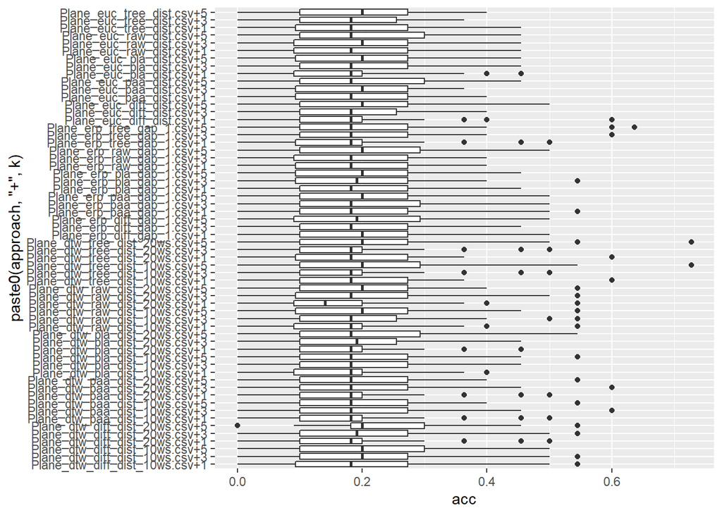

```r
require(ggplot2)
ggplot(overall_results,aes(x=paste0(approach,'+',k), y=acc)) +
geom_boxplot()+
coord_flip()
```